# case_IBM

### Sumário

1. **1. Análise Descritiva**
   - Imports e Leitura
   - 1.1 Propriedades Estatísticas
   - 1.2 Representação das Classes por Variáveis Independentes
   - 1.3 Visualização de conformidade, com relação ao Peso (g)
   - 1.4. Perspectivas da Análise Descritiva
2. **2. Análise Diagnóstica**
   - 2.1 Inferência do Custo
   - 2.2 Correlações Estatísticas e Detecção de Padrões
   - 2.3. Cálculo de significância estatística (p-valor) e R²
     - 2.3.1 Interpretação das Estatísticas - Significância por Classe no Peso
   - 2.4. Perspectivas da Análise Diagnótica
3. **3. Análise Preditiva**
   - 3.1. Pré-processamento
   - 3.2. Avaliação Inicial (Baseline) dos Modelos
   - 3.3.1. Análise de Resíduos
   - 3.4. Otimização de Hiperparâmetros
   - 3.5. Feature Importance do melhor Modelo
4. **4. Análise Prescritiva**
5. **Recomendações Finais**

## **1. Análise Descritiva**

### Imports e Leitura

Importação das bibliotecas que serão utilizadas para leitura e manipulação dos dados.

```python
import pandas as pd
import numpy as np
import matplotlib.pyplot as plt
import seaborn as sns
import warnings

warnings.filterwarnings('ignore')
sns.set_style('whitegrid')
```

```python
df = pd.read_csv("C:/Users/pcdan/Downloads/case_IBM/registros_prod.csv", sep=';',decimal=',', low_memory=False)

# Conversão da variável categórica
df['VAR_2'] = pd.Categorical(df['VAR_2'])
```

```python
df.dtypes
```

```
QTD_CHOC        float64
VAR_1           float64
VAR_2          category
PESO_BOMBOM     float64
dtype: object
```

### 1.1 Propriedades Estatisticas

Etapa para avaliação estatístaca do dataset `registros_prod.csv`, e representação das suas distribuições, dimencionalidade e balanceamento de variáveis **independentes** e **dependente**.

```python
df.info()
```

```
<class 'pandas.core.frame.DataFrame'>
RangeIndex: 500 entries, 0 to 499
Data columns (total 4 columns):
 #   Column       Non-Null Count  Dtype
---  ------       --------------  -----
 0   QTD_CHOC     500 non-null    float64
 1   VAR_1        500 non-null    float64
 2   VAR_2        500 non-null    category
 3   PESO_BOMBOM  500 non-null    float64
dtypes: category(1), float64(3)
memory usage: 12.5 KB
```

```python
df
```

|  | QTD_CHOC | VAR_1 | VAR_2 | PESO_BOMBOM |
| --- | --- | --- | --- | --- |
| 0 | 320.15 | 0.88 | A | 10.144919 |
| 1 | 320.14 | 1.55 | A | 11.547027 |
| 2 | 284.85 | 2.97 | A | 11.112109 |
| 3 | 263.92 | 2.36 | C | 9.900123 |
| 4 | 276.22 | 2.98 | C | 10.079822 |
| ... | ... | ... | ... | ... |
| 495 | 301.01 | 1.59 | A | 10.471494 |
| 496 | 331.41 | 2.60 | A | 12.048504 |
| 497 | 311.08 | 0.38 | C | 6.128060 |
| 498 | 315.56 | 1.89 | B | 9.198321 |
| 499 | 309.30 | 2.91 | A | 12.686713 |

500 rows × 4 columns

```python
numerical_features = df.select_dtypes(include=['float64'])
string_features = df.select_dtypes(include=['category'])


""" Análise exploratória das variáveis numéricas e categórica
# Formato do sino (Skewness)
Skew BEETWEN -0,5 AND 0,5                       - simétricos;
Skew BEETWEN -1 AND -0,5 OR BEETWEN 0,5 AND 1   - moderadamente distorcidos;
Skew > -1 OR > 1                                - altamente distorcidos;

# Achatamento do sino (Kurtosis)
Kurtosis == 0 - distribuição normal;
Kurtosis > 0  - concentrada;
Kurtosis < 0  - menos concentrada;
"""

# Assimetria de features numéricas
df_skewness  = pd.DataFrame(numerical_features.skew(),columns=['skew'])
df_kurtosis  = pd.DataFrame(numerical_features.kurtosis(),columns=['kurtosis'])
df_intervalo = pd.DataFrame(numerical_features.max() - numerical_features.min(),columns=['amplitude'])

print("\nEstatísticas descritivas:")
df_describe = df.describe().T
df_descritive_statistics = pd.concat([df_describe,df_skewness,df_kurtosis,df_intervalo], axis=1)
df_descritive_statistics
```

```
Estatísticas descritivas:
```

|  | count | mean | std | min | 25% | 50% | 75% | max | skew | kurtosis | amplitude |
| --- | --- | --- | --- | --- | --- | --- | --- | --- | --- | --- | --- |
| QTD_CHOC | 500.0 | 291.264600 | 45.182499 | 112.910000 | 259.267500 | 295.450000 | 325.137500 | 436.070000 | -0.268950 | 0.112985 | 323.160000 |
| VAR_1 | 500.0 | 2.098180 | 0.711166 | 0.050000 | 1.630000 | 2.300000 | 2.672500 | 2.980000 | -0.821887 | -0.260328 | 2.930000 |
| PESO_BOMBOM | 500.0 | 10.395002 | 1.572233 | 4.543124 | 9.425819 | 10.334273 | 11.379932 | 17.362728 | 0.277041 | 1.498382 | 12.819604 |

```python
# Group by, por variável categórica
agg_class = df.groupby('VAR_2').agg({
    'QTD_CHOC': ['mean', 'std', 'max', 'min'],
    'VAR_1': ['mean', 'std', 'max', 'min'],
    'PESO_BOMBOM': ['mean', 'std', 'max', 'min']})

agg_class.columns = ['_'.join(col).strip() if col[1] else col[0] for col in agg_class.columns.values]
agg_class.T
```

| VAR_2 | A | B | C |
| --- | --- | --- | --- |
| QTD_CHOC_mean | 323.223608 | 296.256485 | 258.082768 |
| QTD_CHOC_std | 21.682587 | 50.153128 | 31.260362 |
| QTD_CHOC_max | 359.710000 | 436.070000 | 337.090000 |
| QTD_CHOC_min | 281.320000 | 112.910000 | 191.840000 |
| VAR_1_mean | 2.079177 | 2.077394 | 2.134520 |
| VAR_1_std | 0.706620 | 0.742727 | 0.687340 |
| VAR_1_max | 2.980000 | 2.980000 | 2.980000 |
| VAR_1_min | 0.210000 | 0.050000 | 0.080000 |
| PESO_BOMBOM_mean | 11.659115 | 9.595768 | 10.011633 |
| PESO_BOMBOM_std | 0.981347 | 1.153189 | 1.651963 |
| PESO_BOMBOM_max | 14.292523 | 12.256938 | 17.362728 |
| PESO_BOMBOM_min | 9.031698 | 6.963430 | 4.543124 |

| VAR_2 escala_peso | A | B | C |
| --- | --- | --- | --- |
| 4 | 0 | 0 | 1 |
| 6 | 0 | 1 | 3 |
| 7 | 0 | 10 | 13 |
| 8 | 0 | 42 | 13 |
| 9 | 6 | 53 | 59 |
| 10 | 37 | 36 | 60 |
| 11 | 55 | 22 | 17 |
| 12 | 47 | 1 | 4 |
| 13 | 12 | 0 | 1 |
| 14 | 1 | 0 | 3 |
| 16 | 0 | 0 | 1 |
| 17 | 0 | 0 | 2 |

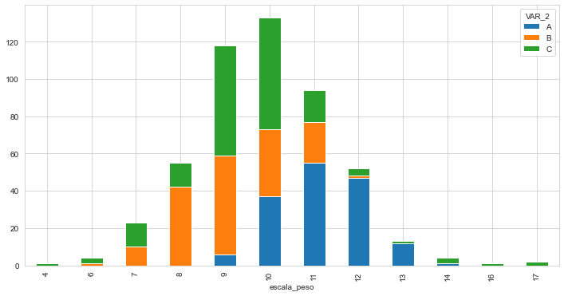

```python
# Agregação de pesos por variável categórica, em escala inteira
df['escala_peso'] = df['PESO_BOMBOM'].astype(int)

agg_class_abs = df.groupby(['VAR_2', 'escala_peso']).size().reset_index(name='count')
agg_class_abs = agg_class_abs.pivot(index='escala_peso', columns='VAR_2', values='count').fillna(0)
display(agg_class_abs)

# Plotando a distribuição dos pesos por variável categórica
plt.figure(figsize=(12, 6))
agg_class_abs.plot(kind='bar', stacked=True, figsize=(12, 6))
```

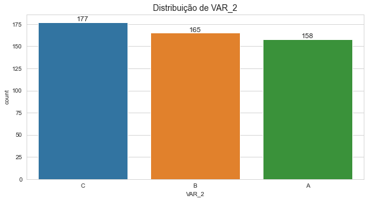

```python
# Distribuição das variável categórica (classes balanceadas)
plt.figure(figsize=(10, 5))
sns.countplot(data=df, x='VAR_2', order=df['VAR_2'].value_counts().index)
plt.bar_label(plt.gca().containers[0], fontsize=12)
plt.title('Distribuição de VAR_2', fontsize=14)
```

```python
# Filtrar dados para QTD_CHOC=mean
subset_mean_qtd = df[(df['QTD_CHOC'] >= 290) & (df['QTD_CHOC'] <= 301)]

# Calcular estatísticas por categoria
stats = subset_mean_qtd.groupby('VAR_2')['PESO_BOMBOM'].agg([
    ('Peso Mínimo', 'min'),
    ('Peso Máximo', 'max'),
    ('Amplitude', lambda x: x.max() - x.min()),
    ('Peso Médio', 'mean'),
    ('Desvio Padrão', 'std'),
    ('% Acima de 10g', lambda x: (x > 10).mean() * 100),
    ('% Abaixo de 9g', lambda x: (x < 9).mean() * 100)
]).round(2)

# Linha de TOTAL
stats.loc['TOTAL'] = subset_mean_qtd['PESO_BOMBOM'].agg({
    'Peso Mínimo': 'min',
    'Peso Máximo': 'max',
    'Amplitude': lambda x: x.max() - x.min(),
    'Peso Médio': 'mean',
    'Desvio Padrão': 'std',
    '% Acima de 10g': lambda x: (x > 10).mean() * 100,
    '% Abaixo de 9g': lambda x: (x < 9).mean() * 100
}).round(2)

stats
```

| VAR_2 | Peso Mínimo | Peso Máximo | Amplitude | Peso Médio | Desvio Padrão | % Acima de 10g | % Abaixo de 9g |
| --- | --- | --- | --- | --- | --- | --- | --- |
| A | 9.46 | 11.86 | 2.40 | 10.70 | 0.67 | 84.21 | 0.00 |
| B | 8.08 | 10.93 | 2.85 | 9.55 | 0.95 | 38.10 | 28.57 |
| C | 7.31 | 11.71 | 4.40 | 10.33 | 1.17 | 81.82 | 9.09 |
| TOTAL | 7.31 | 11.86 | 4.55 | 10.15 | 1.03 | 64.71 | 13.73 |

### 1.2. Representação das Classes por Variáveis Independentes

Identificação das caracteristicas da variável `VAR_2`, e o balanceamento das suas classes. `A`, `B` e `C`

```python
# Configurações gerais para todos os plots
base_figsize = (10, 5)
highlight_color = '#2ecc71'
reference_lines = {
    'y9': {'value': 9, 'color': 'r', 'ls': '--', 'label': 'Limite inferior (9g)'},
    'y10': {'value': 10, 'color': 'g', 'ls': '--', 'label': 'Peso ideal (10g)'}
}

titles = ['Quantidade de Chocolate', 'Variável 1', 'Peso dos Bombons']
xlabels = ['Qtd (g)', 'Variável 1', 'Peso (g)']

numerical_features = df.select_dtypes(include=['float64']).columns
```

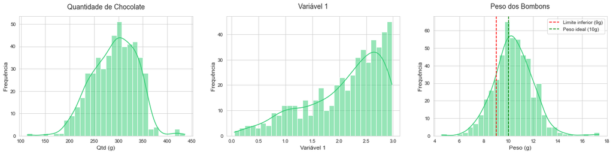

```python
fig, axes = plt.subplots(1, 3, figsize=(18, 5))

# 1. Distribuição das variáveis numéricas
for ax, feature, title, xlabel in zip(axes, numerical_features, titles, xlabels):
    sns.histplot(df[feature], kde=True, bins=30, ax=ax, color=highlight_color)
    ax.set_title(title, fontsize=14, pad=15)
    ax.set_xlabel(xlabel, fontsize=12)
    ax.set_ylabel('Frequência', fontsize=12)

    if feature == 'PESO_BOMBOM':
        for line in reference_lines.values():
            ax.axvline(x=line['value'], color=line['color'],
                       linestyle=line['ls'], linewidth=1.5,
                       label=line['label'])
        ax.legend()

plt.tight_layout(pad=3.0)
plt.show()
```

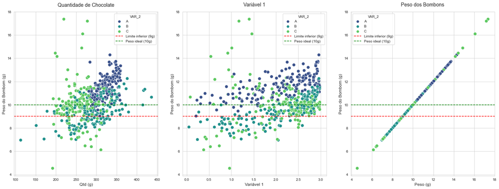

```python
fig, axes = plt.subplots(1, 3, figsize=(20, 8))

# 2. Relação entre Peso e as variáveis numéricas, por VAR_2
for ax, feature, title, xlabel in zip(axes, numerical_features, titles, xlabels):
    sns.scatterplot(x=df[feature], y='PESO_BOMBOM', data=df, hue='VAR_2', palette='viridis', ax=ax, s=80)
    ax.set_title(title, fontsize=14, pad=15)
    ax.set_xlabel(xlabel, fontsize=12)
    ax.set_ylabel('Peso do Bombom (g)', fontsize=12)

    for line in reference_lines.values():
        ax.axhline(y=line['value'], color=line['color'],
                linestyle=line['ls'], linewidth=1.5,
                label=line['label'])

    ax.legend(title='VAR_2')
    plt.tight_layout(pad=3.0)
plt.show()
```

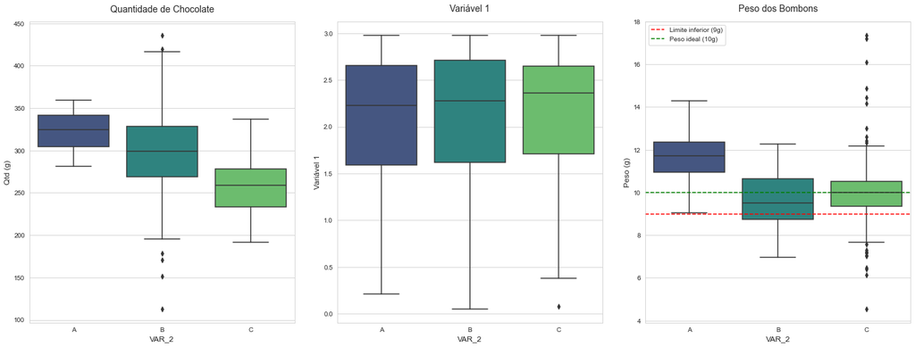

```python
fig, axes = plt.subplots(1, 3, figsize=(20, 8))

# 3. Boxplot por categoria de VAR_2
for ax, feature, title, xlabel in zip(axes, numerical_features, titles, xlabels):
    sns.boxplot(x='VAR_2', y=df[feature], data=df, palette='viridis', ax=ax)
    ax.set_title(title, fontsize=14, pad=15)
    ax.set_xlabel('VAR_2', fontsize=12)
    ax.set_ylabel(xlabel, fontsize=12)

    if feature == 'PESO_BOMBOM':
        for line in reference_lines.values():
            ax.axhline(y=line['value'], color=line['color'],
                    linestyle=line['ls'], linewidth=1.5,
                    label=line['label'])
        ax.legend()
    plt.tight_layout(pad=3.0)
plt.show()
```

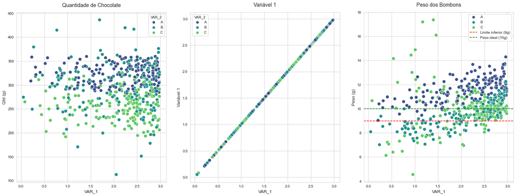

```python
fig, axes = plt.subplots(1, 3, figsize=(20, 8))

# 4. Relação entre VAR_1 e as variáveis numéricas
for ax, feature, title, xlabel in zip(axes, numerical_features, titles, xlabels):
    sns.scatterplot(x='VAR_1', y=df[feature], data=df, hue='VAR_2', palette='viridis', ax=ax, s=80)
    ax.set_title(title, fontsize=14, pad=15)
    ax.set_xlabel('VAR_1', fontsize=12)
    ax.set_ylabel(xlabel, fontsize=12)

    if feature == 'PESO_BOMBOM':
        for line in reference_lines.values():
            ax.axhline(y=line['value'], color=line['color'],
                    linestyle=line['ls'], linewidth=1.5,
                    label=line['label'])
        ax.legend()
    plt.tight_layout(pad=3.0)
plt.show()
```

### 1.3. Visualização de conformidade, com relação ao Peso (g)

Para dar clareza da representação das classes da variável `VAR_2`, foi feita a inferência de uma label (target), chamada `target_peso`, para delimitar as analises por tipo de peso (g). Onde foi considerado seguintes limiares:

**Conformidade (qualidade sugerida pelo cliente)**:

- **Alto** → (>10,0g)
- **Bom** → (9,0g - 10,0g)
- **Ruim** → (<9,0g)

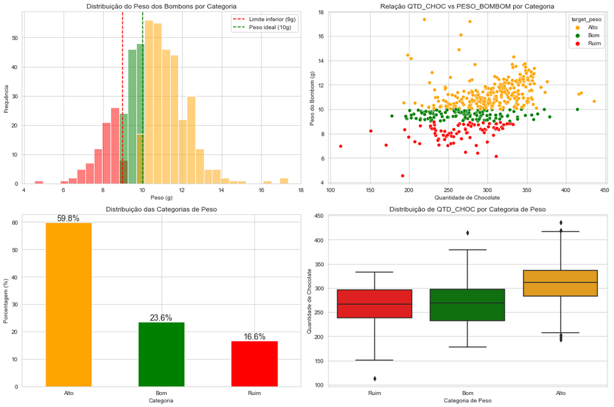

```python
# Classificação do peso
df['target_peso'] = np.where(df['PESO_BOMBOM'] > 10.0, "Alto",
                    np.where((df['PESO_BOMBOM'] >= 9.0) & (df['PESO_BOMBOM'] <= 10.0), "Bom",
                             "Ruim"))

# Categorias de conformidade
conforme = df[(df['PESO_BOMBOM'] >= 9.0) & (df['PESO_BOMBOM'] <= 10.0)]
conforme_custo_alto = df[(df['PESO_BOMBOM'] > 10.0)]
nao_conforme = df[(df['PESO_BOMBOM'] < 9.0)]

plt.figure(figsize=(15, 10))

# Relação Target_Peso vs PESO_BOMBOM com categorias
plt.subplot(2, 2, 1)
sns.histplot(data=df, x='PESO_BOMBOM', hue='target_peso', bins=30, palette={'Ruim': 'red', 'Bom': 'green', 'Alto': 'orange'})
plt.axvline(x=9.0, color='r', linestyle='--', label='Limite inferior (9g)')
plt.axvline(x=10.0, color='g', linestyle='--', label='Peso ideal (10g)')
plt.title('Distribuição do Peso dos Bombons por Categoria')
plt.xlabel('Peso (g)')
plt.ylabel('Frequência')
plt.legend()

# Relação QTD_CHOC vs PESO_BOMBOM com categorias
plt.subplot(2, 2, 2)
sns.scatterplot(x='QTD_CHOC', y='PESO_BOMBOM', hue='target_peso', data=df, palette={'Ruim': 'red', 'Bom': 'green', 'Alto': 'orange'})
plt.title('Relação QTD_CHOC vs PESO_BOMBOM por Categoria')
plt.xlabel('Quantidade de Chocolate')
plt.ylabel('Peso do Bombom (g)')

# Proporção de cada categoria
plt.subplot(2, 2, 3)
categorias = df['target_peso'].value_counts(normalize=True) * 100
categorias.plot(kind='bar', color=['orange', 'green', 'red'])
plt.title('Distribuição das Categorias de Peso')
plt.xlabel('Categoria')
plt.ylabel('Porcentagem (%)')
plt.bar_label(plt.gca().containers[0], fmt='%.1f%%', fontsize=14)
plt.xticks(rotation=0)

# Boxplot de QTD_CHOC por categoria
plt.subplot(2, 2, 4)
sns.boxplot(x='target_peso', y='QTD_CHOC', data=df, order=['Ruim', 'Bom', 'Alto'], palette={'Ruim': 'red', 'Bom': 'green', 'Alto': 'orange'})
plt.title('Distribuição de QTD_CHOC por Categoria de Peso')
plt.xlabel('Categoria de Peso')
plt.ylabel('Quantidade de Chocolate')

plt.tight_layout()
plt.show()
```

```python
df.groupby('target_peso').size().reset_index(name='counts')
```

|  | target_peso | counts |
| --- | --- | --- |
| 0 | Alto | 299 |
| 1 | Bom | 118 |
| 2 | Ruim | 83 |

```python
print("\nDistribuição da variável target_custo:")
result_custo_class = (
    df.groupby(['target_peso', 'VAR_2'])
    .agg({'QTD_CHOC': 'count'})
    .rename(columns={'QTD_CHOC': 'counts'})
)
result_custo_class
```

```
Distribuição da variável target_custo:
```

| target_peso | VAR_2 | counts |
| --- | --- | --- |
| Alto | A | 152 |
|  | B | 59 |
|  | C | 88 |
| Bom | A | 6 |
|  | B | 53 |
|  | C | 59 |
| Ruim | A | 0 |
|  | B | 53 |
|  | C | 30 |

```python
# Dispersão do target_peso com relação ao peso
agg_custo_peso = df.groupby(['target_peso', 'VAR_2']).agg({
    'PESO_BOMBOM': ['mean', 'std', 'max', 'min']})

agg_custo_peso.columns = ['_'.join(col).strip() if col[1] else col[0] for col in agg_custo_peso.columns.values]
agg_custo_peso
```

| target_peso | VAR_2 | PESO_BOMBOM_mean | PESO_BOMBOM_std | PESO_BOMBOM_max | PESO_BOMBOM_min |
| --- | --- | --- | --- | --- | --- |
| Alto | A | 11.740239 | 0.907287 | 14.292523 | 10.017561 |
|  | B | 10.867486 | 0.449601 | 12.256938 | 10.014957 |
|  | C | 11.063377 | 1.461022 | 17.362728 | 10.011102 |
| Bom | A | 9.603972 | 0.333728 | 9.914430 | 9.031698 |
|  | B | 9.498093 | 0.298332 | 9.996741 | 9.028357 |
|  | C | 9.595986 | 0.279243 | 9.994334 | 9.036513 |
| Ruim | A | NaN | NaN | NaN | NaN |
|  | B | 8.277757 | 0.514202 | 8.922604 | 6.963430 |
|  | C | 7.743955 | 0.987208 | 8.966839 | 4.543124 |

```python
# Dispersão do target_peso e VAR_2 com relação a quantidade
agg_custo_qtd = df.groupby(['target_peso', 'VAR_2']).agg({
    'QTD_CHOC': ['mean', 'std', 'max', 'min']})

agg_custo_qtd.columns = ['_'.join(col).strip() if col[1] else col[0] for col in agg_custo_qtd.columns.values]
agg_custo_qtd
```

| target_peso | VAR_2 | QTD_CHOC_mean | QTD_CHOC_std | QTD_CHOC_max | QTD_CHOC_min |
| --- | --- | --- | --- | --- | --- |
| Alto | A | 324.245921 | 21.427259 | 359.71 | 281.32 |
|  | B | 323.871525 | 39.613994 | 436.07 | 246.83 |
|  | C | 265.897841 | 30.676610 | 337.09 | 193.35 |
| Bom | A | 297.325000 | 7.740849 | 308.38 | 287.78 |
|  | B | 293.161887 | 49.342729 | 414.61 | 178.15 |
|  | C | 247.035254 | 28.372111 | 325.48 | 197.22 |
| Ruim | A | NaN | NaN | NaN | NaN |
|  | B | 268.609811 | 45.759105 | 332.72 | 112.91 |
|  | C | 256.885333 | 32.594780 | 312.04 | 191.84 |

```python
# Cálculo da distribuição percentual - Por Classe
agg_class = (
    df.groupby(['target_peso', 'VAR_2'])
    .size()
    .unstack(fill_value=0)
    .round(0)
)

agg_percent = agg_class.div(agg_class.sum(axis=0))*100
agg_percent_tl = pd.concat([
    agg_class.add_suffix('_n'),
    agg_percent.round(1).add_suffix('_%')
], axis=1)

agg_percent_tl.loc['Total'] = agg_percent_tl.sum(axis=0)

agg_percent_tl
```

| VAR_2 target_peso | A_n | B_n | C_n | A_% | B_% | C_% |
| --- | --- | --- | --- | --- | --- | --- |
| Alto | 152.0 | 59.0 | 88.0 | 96.2 | 35.8 | 49.7 |
| Bom | 6.0 | 53.0 | 59.0 | 3.8 | 32.1 | 33.3 |
| Ruim | 0.0 | 53.0 | 30.0 | 0.0 | 32.1 | 16.9 |
| Total | 158.0 | 165.0 | 177.0 | 100.0 | 100.0 | 99.9 |

```python
# Cálculo da distribuição percentual - Por Target Peso
agg_target_percentil = (
    df.groupby(['target_peso', 'VAR_2'])
    .size()
    .unstack(fill_value=0)
    .apply(lambda x: x/x.sum()*100, axis=1)
    .round(0)
)
agg_target_percentil['Total'] = agg_target_percentil.sum(axis=1)
agg_target_percentil
```

| VAR_2 target_peso | A | B | C | Total |
| --- | --- | --- | --- | --- |
| Alto | 51.0 | 20.0 | 29.0 | 100.0 |
| Bom | 5.0 | 45.0 | 50.0 | 100.0 |
| Ruim | 0.0 | 64.0 | 36.0 | 100.0 |

```python
# Análise de conformidade
print(f"Porcentagem de bombons conformes: {len(conforme)/len(df)*100:.2f}%")
print(f"Porcentagem de bombons conformes, porém com custo alto: {len(conforme_custo_alto)/len(df)*100:.2f}%")
print(f"Porcentagem de bombons não conformes: {len(nao_conforme)/len(df)*100:.2f}%")
```

```
Porcentagem de bombons conformes: 23.60%
Porcentagem de bombons conformes, porém com custo alto: 59.80%
Porcentagem de bombons não conformes: 16.60%
```

### 1.4. Perspectivas da Análise Descritiva:

1. **Distribuição do `PESO_BOMBOM`**:  
   Alta variabilidade, com apenas **23% dos bombons** na faixa ideal (9.0g - 10.0g).
2. **Relação de `QTD_CHOC`**:  
   Embora exista correlação entre quantidade de chocolate (`QTD_CHOC`) e peso (`PESO_BOMBOM`), a dispersão é crítica:
   - Para **QTD_CHOC=300g** (média peso), o peso varia entre **7.3g a 11.9g**.
3. **Impacto de `VAR_2`**:  
   As classes apresentam comportamentos distintos:
   - **Classe A**:
     - **Média de 11.7g** (acima do ideal)
     - Dominada por produtos **"Alto" (96,2%)** → Problema de superdosagem
     - Quase sem produtos "Bons" (3,8%) → Processo estável mas mal calibrado
   - **Classe B**:
     - **Média de 9.6g** (próximo do ideal)
     - Distribuição mais equilibrada, mas com:
     - 32,1% **"Ruim"** (descarte)
     - 35,8% **"Alto"** (custo)
     - Necessidade urgente de controle de `VAR_1`
   - **Classe C**:
     - **Média de 10.0g** (Ideal)
     - 49,7% **"Alto"** + 16,9% **"Ruim"** → Processo ineficiente
     - Apenas 33,3% na faixa ideal ("Bom")
4. **Conformidade e Custo**:
   - **59,8% "Alto"** → (> 10.0g)
   - **23,6% "Bom"** → (9.0g - 10.0g)
   - **16,6% "Ruim"** → (< 9.0g) Perda direta de produto*

#### Problema:

- **Eficiência comprometida**: 77% da produção gera custos acima do ideal (60% por excesso, 17% por perda).
- **Classe A** é a maior responsável pelo custo elevado (51,0% dos casos).
- **Classe B e C** apresentam risco operacional crítico (Totalizando ambas, é mesmo que dizer 1 em cada 4 bombons são descartados).
- Temos um problema de **regressão**, onde precisamos predizer o valor do peso com base nas várias de entrada, para minimizar custo. Logo isso, nos levará a identificar os principais ranges de input.

## **2. Análise Diagnóstica**

### 2.1. Inferência do Custo

Criando de função de custo, para inferir resultado. Com base na função pré-definida do cliente.

$$ C(p) = \frac{200}{1 + e^{10(p - 9.5)}} + \frac{200}{1 + e^{-0.8(p - 12)}} $$

```python
# Definir a função de custo
def calcular_custo(p):
    """
    Calcula o custo C(p) baseado no peso p do bombom.

    Parâmetros:
    p -- peso do bombom (float)

    Retorna:
    Valor do custo calculado
    """
    termo1 = 200 / (1 + np.exp(10 * (p - 9.5)))
    termo2 = 200 / (1 + np.exp(-0.8 * (p - 12)))
    return termo1 + termo2

df['custo'] = calcular_custo(df['PESO_BOMBOM'])

print("\nEstatísticas descritivas do custo:")
df_custo = df['custo'].describe().to_frame(name='custo')
df_custo
```

```
Estatísticas descritivas do custo:
```

|  | custo |
| --- | --- |
| count | 500.000000 |
| mean | 107.161983 |
| std | 65.647587 |
| min | 34.690631 |
| 25% | 49.183556 |
| 50% | 82.358225 |
| 75% | 173.128378 |
| max | 215.271798 |

```python
# Dispersão do custo com relação ao VAR_2
agg_custo_cat = df.groupby(['VAR_2']).agg({
    'custo': ['mean', 'std', 'max', 'min']})

agg_custo_cat.columns = ['_'.join(col).strip() if col[1] else col[0] for col in agg_custo_cat.columns.values]
agg_custo_cat
```

| VAR_2 | custo_mean | custo_std | custo_max | custo_min |
| --- | --- | --- | --- | --- |
| A | 90.675555 | 34.759385 | 215.192145 | 34.847450 |
| B | 129.961947 | 75.307632 | 215.210262 | 34.693995 |
| C | 100.624477 | 71.288361 | 215.271798 | 34.690631 |

```python
# Cálculo da distribuição percentual do custo- Por Classe
agg_class = (
    df[['target_peso', 'VAR_2','custo']].groupby(['target_peso', 'VAR_2'])
    .sum('custo')
    .unstack(fill_value=0)
    .round(0)
)

agg_percent = agg_class.div(agg_class.sum(axis=0))*100
agg_percent_tl = pd.concat([
    agg_class.add_suffix('_n'),
    agg_percent.round(1).add_suffix('_%')
], axis=1)

agg_percent_tl.loc['Total'] = agg_percent_tl.sum(axis=0)

agg_percent_tl
```

| VAR_2 target_peso | custo_n A_n | custo_n B_n | custo_n C_n | custo_% A_% | custo_% B_% | custo_% C_% |
| --- | --- | --- | --- | --- | --- | --- |
| Alto | 13759.0 | 3459.0 | 5652.0 | 96.0 | 16.1 | 31.7 |
| Bom | 567.0 | 6841.0 | 5923.0 | 4.0 | 31.9 | 33.3 |
| Ruim | 0.0 | 11143.0 | 6236.0 | 0.0 | 52.0 | 35.0 |
| Total | 14326.0 | 21443.0 | 17811.0 | 100.0 | 100.0 | 100.0 |

```python
# Cálculo da distribuição percentual - Por Target Peso
agg_target_percentil = (
    df[['target_peso', 'VAR_2','custo']].groupby(['target_peso', 'VAR_2'])
    .sum('custo')
    .unstack(fill_value=0)
    .apply(lambda x: x/x.sum()*100, axis=1)
    .round(0)
)
agg_target_percentil['Total'] = agg_target_percentil.sum(axis=1)
agg_target_percentil
```

| VAR_2 target_peso | custo A | custo B | custo C | Total |
| --- | --- | --- | --- | --- |
| Alto | 60.0 | 15.0 | 25.0 | 100.0 |
| Bom | 4.0 | 51.0 | 44.0 | 99.0 |
| Ruim | 0.0 | 64.0 | 36.0 | 100.0 |

```python
# Dispersão do custo com relação ao target_peso e VAR_2
agg_custo_cat = df.groupby(['target_peso', 'VAR_2']).agg({
    'custo': ['mean', 'std', 'max', 'min']})

agg_custo_cat.columns = ['_'.join(col).strip() if col[1] else col[0] for col in agg_custo_cat.columns.values]
agg_custo_cat
```

| target_peso | VAR_2 | custo_mean | custo_std | custo_max | custo_min |
| --- | --- | --- | --- | --- | --- |
| Alto | A | 90.521437 | 32.815560 | 172.447952 | 35.115057 |
|  | B | 58.626557 | 14.939404 | 110.241472 | 35.085807 |
|  | C | 64.227615 | 40.003530 | 197.296559 | 35.044076 |
| Bom | A | 94.579875 | 73.469247 | 215.192145 | 34.847450 |
|  | B | 129.083527 | 72.670948 | 215.210262 | 34.693995 |
|  | C | 100.385432 | 71.088338 | 215.162674 | 34.690631 |
| Ruim | A | NaN | NaN | NaN | NaN |
|  | B | 210.251463 | 3.360004 | 215.094732 | 203.495338 |
|  | C | 207.858725 | 4.360900 | 215.271798 | 200.511839 |

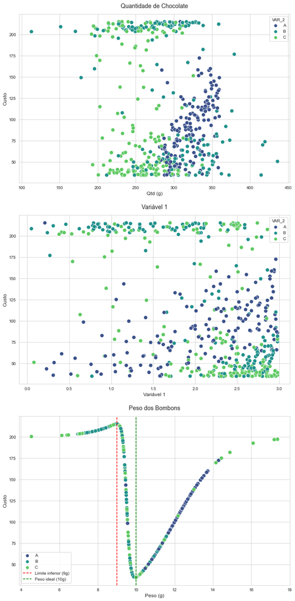

```python
fig, axes = plt.subplots(3, 1, figsize=(10, 20))

# 4. Relação entre Custo e as variáveis numéricas
for ax, feature, title, xlabel in zip(axes, numerical_features, titles, xlabels):
    sns.scatterplot(x=df[feature], y='custo', data=df, hue='VAR_2', palette='viridis', ax=ax, s=80)
    ax.set_title(title, fontsize=14, pad=15)
    ax.set_xlabel(xlabel, fontsize=12)
    ax.set_ylabel('Custo', fontsize=12)

    if feature == 'PESO_BOMBOM':
        for line in reference_lines.values():
            ax.axvline(x=line['value'], color=line['color'],
                    linestyle=line['ls'], linewidth=1.5,
                    label=line['label'])
        ax.legend()
    plt.tight_layout(pad=2.0)
plt.show()
```

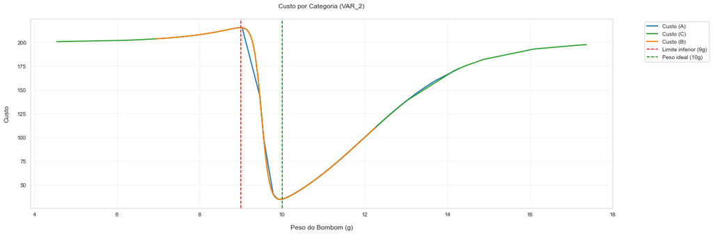

```python
# Custo por categoria VAR_2
plt.figure(figsize=(18, 6))
colors = {'A': '#1f77b4', 'B': '#ff7f0e', 'C': '#2ca02c'}

for categoria in df['VAR_2'].unique():
    subset = df[df['VAR_2'] == categoria].sort_values('PESO_BOMBOM')  # assumindo que a coluna de peso se chama 'peso'

    # Plotar linha
    plt.plot(subset['PESO_BOMBOM'], subset['custo'],
             color=colors[categoria],
             linestyle='-',
             linewidth=2,
             label=f'Custo ({categoria})')

# Linhas de referência
plt.axvline(x=9, color='r', linestyle='--', label='Limite inferior (9g)')
plt.axvline(x=10, color='g', linestyle='--', label='Peso ideal (10g)')

plt.title('Custo por Categoria (VAR_2)', pad=20)
plt.xlabel('Peso do Bombom (g)', labelpad=14, fontsize=12)
plt.ylabel('Custo', labelpad=14, fontsize=12)
plt.grid(alpha=0.3)
plt.legend(bbox_to_anchor=(1.05, 1), loc='upper left')
plt.tight_layout()

plt.show()
```

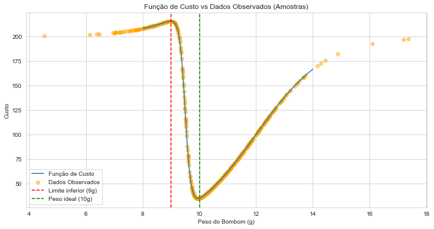

```python
# Visualizar a função de custo
p_range = np.linspace(8, 14, 100)
custo_range = calcular_custo(p_range)

plt.figure(figsize=(12, 6))
plt.plot(p_range, custo_range, label='Função de Custo')
plt.scatter(df['PESO_BOMBOM'], df['custo'], color='orange', alpha=0.5, label='Dados Observados')
plt.axvline(x=9, color='r', linestyle='--', label='Limite inferior (9g)')
plt.axvline(x=10, color='g', linestyle='--', label='Peso ideal (10g)')
plt.title('Função de Custo vs Dados Observados (Amostras)')
plt.xlabel('Peso do Bombom (g)')
plt.ylabel('Custo')
plt.legend()
plt.show()
```

### 2.2. Correlações Estatísticas e Detecção de Padrões

Exploramos as relações entre **`QTD_CHOC`**, **`VAR_1`**, **`VAR_2`** e **`PESO_BOMBOM`** para identificar padrões ocultos e direcionar ações de controle.

```python
# Calculando correlações
df_corr = df[['QTD_CHOC', 'VAR_1', 'PESO_BOMBOM', 'custo']].copy()
corr_matrix = df_corr.corr(numeric_only=True)
corr_matrix
```

|  | QTD_CHOC | VAR_1 | PESO_BOMBOM | custo |
| --- | --- | --- | --- | --- |
| QTD_CHOC | 1.000000 | -0.029062 | 0.437217 | -0.184706 |
| VAR_1 | -0.029062 | 1.000000 | 0.316657 | -0.352085 |
| PESO_BOMBOM | 0.437217 | 0.316657 | 1.000000 | -0.384280 |
| custo | -0.184706 | -0.352085 | -0.384280 | 1.000000 |

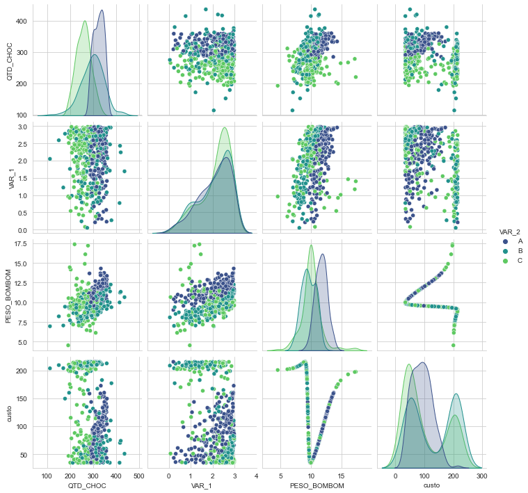

```python
sns.pairplot(df, hue='VAR_2', vars=['QTD_CHOC', 'VAR_1', 'PESO_BOMBOM', 'custo'], palette='viridis')
plt.show()
```

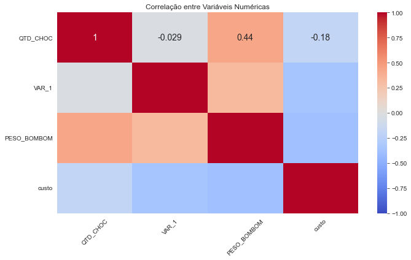

```python
# Plotando heatmap
plt.figure(figsize=(10, 6))
sns.heatmap(
    corr_matrix,
    annot=True,
    annot_kws={"size": 14},
    cmap='coolwarm',
    vmin=-1,
    vmax=1
)
plt.title("Correlação entre Variáveis Numéricas")
plt.yticks(rotation=0)
plt.xticks(rotation=45)
plt.tight_layout()
plt.show()
```

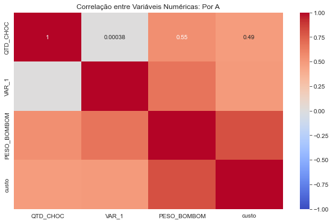

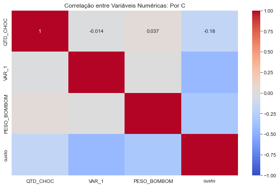

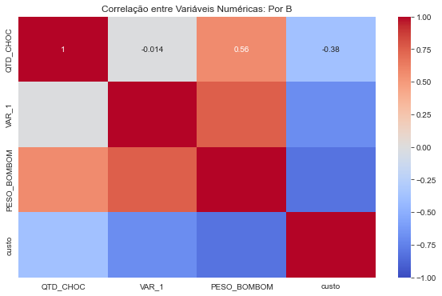

```python
class_VAR_2 = df['VAR_2'].unique().to_list()

for i in class_VAR_2:
    df_class = df[df['VAR_2'] == i]
    corr_matrix = df_class.corr(numeric_only=True)

    # Plotando heatmap
    plt.figure(figsize=(10, 6))
    sns.heatmap(corr_matrix, annot=True, cmap='coolwarm', vmin=-1, vmax=1)
    plt.title("Correlação entre Variáveis Numéricas: Por " + str(i))
    plt.show()
```

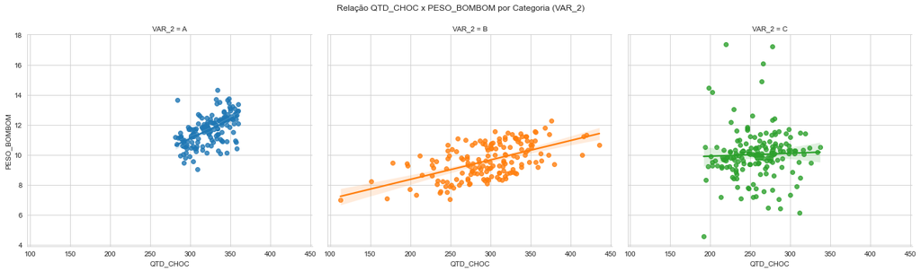

```python
# Relação Linear entre QTD_CHOC e PESO_BOMBOM por classe (VAR_2)
sns.lmplot(
    data=df, x="QTD_CHOC", y="PESO_BOMBOM",
    hue="VAR_2", col="VAR_2", ci=95,
    height=5, aspect=1.2
)
plt.suptitle("Relação QTD_CHOC x PESO_BOMBOM por Categoria (VAR_2)", y=1.05)
plt.show()
```

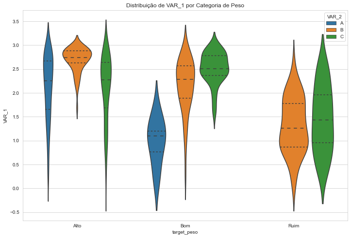

```python
# Distribuição de VAR_1 por target_peso e VAR_2
plt.figure(figsize=(12, 8))
sns.violinplot(data=df, x="target_peso", y="VAR_1", hue="VAR_2", inner="quartile")
plt.title("Distribuição de VAR_1 por Categoria de Peso")
plt.show()
```

[figure not shown]

```python
plt.figure(figsize=(12, 8))
sns.violinplot(data=df, x="target_peso", y="PESO_BOMBOM", hue="VAR_2", inner="quartile")
plt.title("Distribuição de VAR_1 por Categoria de Peso")
plt.show()
```

[figure not shown]

```python
plt.figure(figsize=(12, 8))
sns.violinplot(data=df, x="target_peso", y="QTD_CHOC", hue="VAR_2", inner="quartile")
plt.title("Distribuição de VAR_1 por Categoria de Peso")
plt.show()
```

```python
# VAR_1 para classe B e C, com base no target_peso = Ruim
list_class = ['B', 'C']
df_valid = df[(df['VAR_2'].isin(list_class)) & (df['VAR_1'] < 2.0)]
df_valid['escala_VAR1'] = round(df_valid['VAR_1'] * 2) / 2
agg_class_abs = df_valid.groupby(['escala_VAR1', 'target_peso']).size().reset_index(name='count')
agg_class_abs = agg_class_abs.pivot(index='escala_VAR1', columns='target_peso', values='count').fillna(0)
agg_class_abs = agg_class_abs.astype(int)

display(agg_class_abs)

print(f"VAR_1, para influencia de Target Peso == Ruim: {round((67/83)*100,1)}%")
```

| target_peso escala_VAR1 | Alto | Bom | Ruim |
| --- | --- | --- | --- |
| 0.0 | 1 | 0 | 2 |
| 0.5 | 3 | 1 | 10 |
| 1.0 | 10 | 3 | 28 |
| 1.5 | 10 | 8 | 18 |
| 2.0 | 4 | 12 | 9 |

```
VAR_1, para influencia de Target Peso == Ruim: 80.7%
```

```python
# VAR_1 para classe A, B e C, com base no target_peso = Alto
list_class = ['A', 'B', 'C']
df_valid = df[(df['VAR_2'].isin(list_class)) & (df['target_peso'] == 'Alto')]
df_valid['escala_VAR1'] = round(df_valid['VAR_1'] * 2) / 2
agg_class_abs = df_valid.groupby(['escala_VAR1', 'target_peso', 'VAR_2']).size().reset_index(name='count')
display(agg_class_abs.sort_values(by='escala_VAR1', ascending=False))

var_1_alto = agg_class_abs['count'].sum()
var_1_alto_limit = agg_class_abs[agg_class_abs['escala_VAR1'] >= 2.0]['count'].sum()

print(f"VAR_1, para influencia de Target Peso == Alto: {round((var_1_alto_limit/var_1_alto)*100,1)}%")
```

|  | escala_VAR1 | target_peso | VAR_2 | count |
| --- | --- | --- | --- | --- |
| 20 | 3.0 | Alto | C | 16 |
| 18 | 3.0 | Alto | A | 32 |
| 19 | 3.0 | Alto | B | 29 |
| 16 | 2.5 | Alto | B | 25 |
| 17 | 2.5 | Alto | C | 28 |
| 15 | 2.5 | Alto | A | 43 |
| 14 | 2.0 | Alto | C | 21 |
| 12 | 2.0 | Alto | A | 33 |
| 13 | 2.0 | Alto | B | 4 |
| 11 | 1.5 | Alto | C | 9 |
| 10 | 1.5 | Alto | B | 1 |
| 9 | 1.5 | Alto | A | 24 |
| 8 | 1.0 | Alto | C | 10 |
| 7 | 1.0 | Alto | B | 0 |
| 6 | 1.0 | Alto | A | 14 |
| 4 | 0.5 | Alto | B | 0 |
| 3 | 0.5 | Alto | A | 5 |
| 5 | 0.5 | Alto | C | 3 |
| 1 | 0.0 | Alto | B | 0 |
| 0 | 0.0 | Alto | A | 1 |
| 2 | 0.0 | Alto | C | 1 |

[output not shown]

### 2.3. Cálculo de significância estatística (p-valor) e R²

Modelando o `PESO_BOMBOM` em Função de `QTD_CHOC` e `VAR_1`

```python
from sklearn.linear_model import LinearRegression

list_class = df["VAR_2"].unique().to_list()
results_list = []

for i in list_class:
    subset = df[df["VAR_2"] == i]
    X = subset[["QTD_CHOC", "VAR_1"]]
    y = subset["PESO_BOMBOM"]

    model = LinearRegression().fit(X, y)

    results_list.append({
        'Classe': i,
        'Coef_QTD_CHOC': model.coef_[0],
        'Coef_VAR_1': model.coef_[1],
        'R2': model.score(X, y)
    })

results_df = pd.DataFrame(results_list)
results_df = results_df.round(4)

results_df.sort_values(by='Classe')
```

|  | Classe | Coef_QTD_CHOC | Coef_VAR_1 | R2 |
| --- | --- | --- | --- | --- |
| 0 | A | 0.0249 | 0.9267 | 0.7493 |
| 2 | B | 0.0132 | 1.1885 | 0.9031 |
| 1 | C | 0.0020 | 0.0149 | 0.0014 |

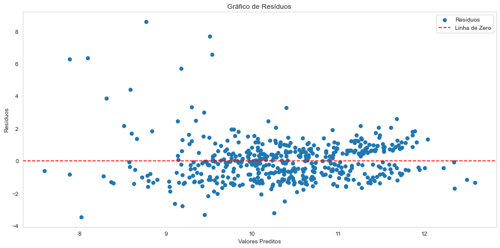

```python
# Suponha que X e y sejam seus dados
subset = df.copy()
X = subset[["QTD_CHOC", "VAR_1"]]
y = subset["PESO_BOMBOM"]

model = LinearRegression()
model.fit(X, y)
y_pred = model.predict(X)
residuos = y - y_pred

plt.figure(figsize=(12, 6))
plt.scatter(y_pred, residuos)
plt.axhline(y=0, color='r', linestyle='--')
plt.xlabel("Valores Preditos")
plt.ylabel("Resíduos")
plt.title("Gráfico de Resíduos")
plt.legend(["Resíduos", "Linha de Zero"])
plt.grid()
plt.tight_layout()
plt.show()
```

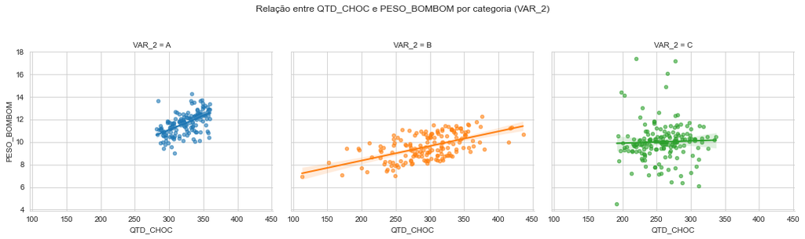

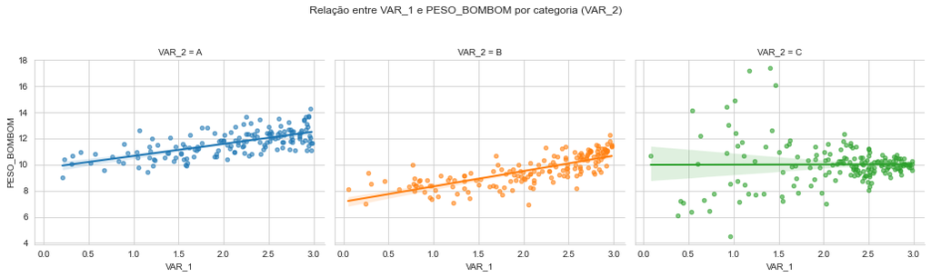

```python
# Gráficos de dispersão por classe - Avaliação de Linearidade
# Relação Linear entre PESO_BOMBOM por classe (VAR_2)
features_list = ['QTD_CHOC', 'VAR_1']

# Configuração dos gráficos
for feature in features_list:
    sns.lmplot(
        data=df,
        x=feature,
        y="PESO_BOMBOM",
        hue="VAR_2",
        col="VAR_2",
        ci=95,
        height=4,
        aspect=1.2,
        scatter_kws={'s': 20, 'alpha': 0.6},
        line_kws={'lw': 2}
    )
    plt.suptitle(f"Relação entre {feature} e PESO_BOMBOM por categoria (VAR_2)", y=1.05)
    plt.tight_layout()
    plt.show()
```

#### **2.3.1. Interpretação das Estatísticas - Significância por Classe no Peso**

##### **1. Classe A**

- **Impacto de `QTD_CHOC` (0.0249)**:
  - Para cada 1g adicional de chocolate, o peso do bombom aumenta **0.0249g**.
  - Exemplo, é necessário ~40g (Calc: 1.0g / 0.0249g) de chocolate para ganhar 1g no produto final.
- **Impacto de `VAR_1` (0.9267)**:
  - **Fator**: Cada aumento unitário em `VAR_1` aumenta o peso em **0.9267g**.
  - **Sensibilidade**: Variável crítica para controle de qualidade.
- **R² (0.7493)**:
  - O modelo explica **74.9%** da variação no peso. E `VAR_1` é o principal fator, mas `QTD_CHOC` tem uma contribuição relevante também.

##### **2. Classe B**

- **Impacto de `QTD_CHOC` (0.0132)**:
  - Para cada 1g adicional de chocolate, o peso do bombom aumenta **0.0132g**.
  - Exemplo, é necessário ~75g (Calc: 1.0g / 0.0132g) de chocolate para ganhar 1g no produto final.
- **Impacto de `VAR_1` (1.1885)**:
  - **Fator**: Cada aumento unitário em `VAR_1` aumenta o peso em **1.1885g** (Maior entre todas as classes).
  - **Sensibilidade**: Variável crítica, pequenas variações em `VAR_1` causam grandes mudanças no peso.
- **R² (0.9031)**:
  - Modelo explica **90.31%** da variação no peso. Em resumo, `VAR_1` é **extremamente determinante**, e `QTD_CHOC` tem papel secundário.

##### **3. Classe C**

- **Impacto de `QTD_CHOC` (0.0020)**:
  - Para cada 1g adicional de chocolate, o peso do bombom aumenta **0.0020g**.
  - Exemplo, é necessário ~500g (Calc: 1.0g / 0.0020g) de chocolate para ganhar 1g no produto final (Relevância, praticamente inexistente).
- **Impacto de `VAR_1` (0.0149)**:
  - **Fator**: Cada aumento unitário em `VAR_1` aumenta o peso em **0.0149g**.
  - **Sensibilidade**: Variável quase irrelevante, com relação ao peso.
- **R² (0.0014)**:
  - Modelo não explica a variação do peso (R² apenas 0.14%). Outros fatores não mapeados podem dominam o processo.

### 2.4. Perspectivas da Análise Diagnótica:

**Principais Insights:**

**Conclusões e Ações Prioritárias**

- **Classe A**:
  - Reduzir `QTD_CHOC` em **15%** (evitar excesso de peso).
  - Monitorar estabilidade do processo (baixa variabilidade).
- **Classe B**:
  - Implementar sistema de alerta para `VAR_1 < 2.0` (evitar produtos "Ruim", e reduzir 32.1% de "Ruim")
  - Controlar `VAR_1` **> 2.0** (evitar produtos "Ruim").
  - Implementar ajuste automático de `QTD_CHOC` baseado em `VAR_1`.
- **Classe C**:
  - Testar aumento de **5%** em `QTD_CHOC` como medida emergencial.
2. **Monitoramento em Tempo Real**
- Monitorar **`VAR_1` em tempo real** (principalmente para B, onde tem maior impacto).
- Ajustar `QTD_CHOC` com base em `VAR_1` para evitar excesso (A) ou falta de peso (B).

**Impacto Esperado**:

- Redução de **20-30%** nos custos (Classe A).
- Queda maior ou igual a **15%** em produtos não conformes (Classes B/C).

**Próximos Passos seriam:**

- **Piloto de Otimização**:
  - Aplicar ajustes propostos em **lotes controlados** (10% da produção).
  - Medir impacto em custo e conformidade.
- **Dashboard de Controle**:
  - Exibir relação em tempo real entre `VAR_1`, `QTD_CHOC` e peso por categoria (`PESO_BOMBOM`).
- Desenvolver **modelo preditivo** para simular cenários.
- Testar **valores ótimos** em produção piloto.

## **3. Análise Preditiva**

```python
from sklearn.model_selection import train_test_split, GridSearchCV
from sklearn.preprocessing import OneHotEncoder
from sklearn.compose import ColumnTransformer
from sklearn.pipeline import Pipeline
from sklearn.linear_model import LinearRegression
from sklearn.ensemble import RandomForestRegressor, GradientBoostingRegressor
from sklearn.metrics import mean_squared_error, r2_score

import pandas as pd
import numpy as np
import matplotlib.pyplot as plt
import seaborn as sns
import warnings

warnings.filterwarnings('ignore')
sns.set_style('whitegrid')
```

```python
df = pd.read_csv("C:/Users/pcdan/Downloads/case_IBM/registros_prod.csv", sep=';', decimal=',', low_memory=False)

## Conversão da variável categórica
df['VAR_2'] = pd.Categorical(df['VAR_2'])
```

### 3.1. Pré-processamento

Ajuste e outliers e incremento de features de interação (`QTD_CHOC` * `VAR_1`)

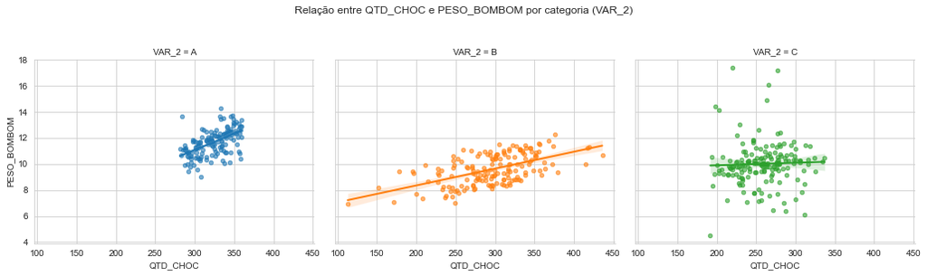

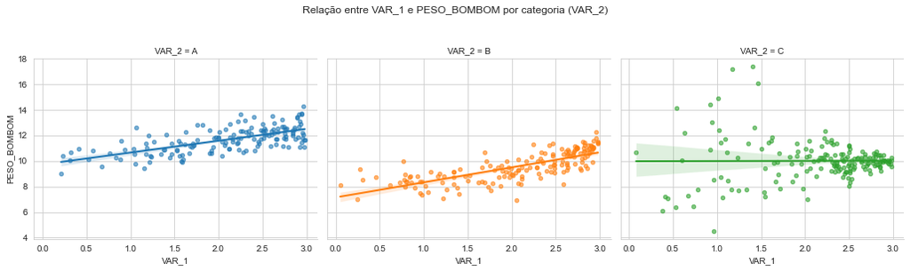

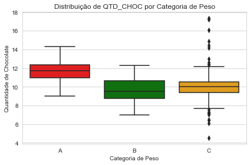

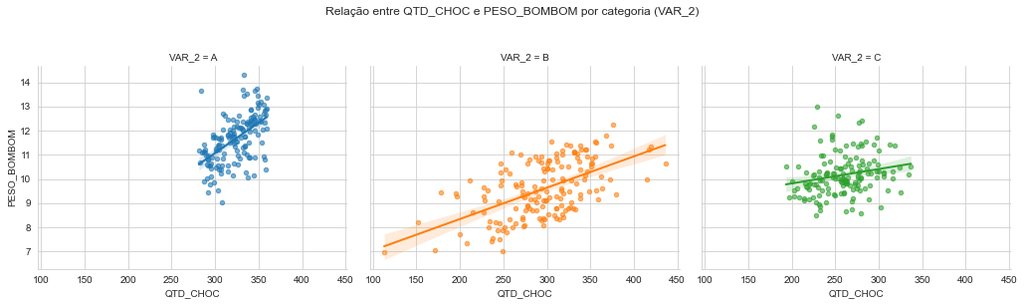

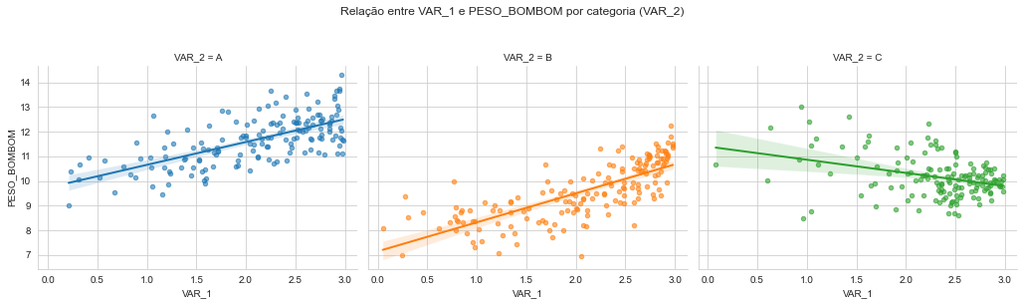

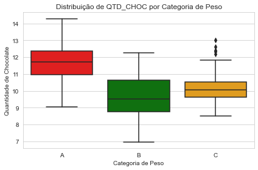

```python
def plot_outliers(df_input):
    df = df_input

    features_list = ['QTD_CHOC', 'VAR_1']

    # Configuração dos gráficos
    for feature in features_list:
        sns.lmplot(
            data=df,
            x=feature,
            y="PESO_BOMBOM",
            hue="VAR_2",
            col="VAR_2",
            ci=95,
            height=4,
            aspect=1.2,
            scatter_kws={'s': 20, 'alpha': 0.6},
            line_kws={'lw': 2}
        )
        plt.suptitle(f"Relação entre {feature} e PESO_BOMBOM por categoria (VAR_2)", y=1.05)
        plt.tight_layout()
        plt.show()

    # Boxplot de QTD_CHOC por categoria
    sns.boxplot(x='VAR_2', y='PESO_BOMBOM', data=df, order=['A', 'B', 'C'], palette={'A': 'red', 'B': 'green', 'C': 'orange'})
    plt.title('Distribuição de QTD_CHOC por Categoria de Peso')
    plt.xlabel('Categoria de Peso')
    plt.ylabel('Quantidade de Chocolate')

    plt.tight_layout()
    plt.show()

## Antes de remover os outliers da classe C
plot_outliers(df)

## Depois de remover os outliers da classe C
df_out = df[~((df['VAR_2'] == 'C') & ((df['PESO_BOMBOM'] > 14.0) | (df['PESO_BOMBOM'] < 8.5)))]
# Interação de features
df_out['INTERACTION'] = df_out['QTD_CHOC'] * df_out['VAR_1']
plot_outliers(df_out)
```

```python
# Pré-processamento
preprocessor = ColumnTransformer(transformers=[('cat', OneHotEncoder(drop=None), ['VAR_2'])], remainder='passthrough')

# Dividir dados
X = df_out[['QTD_CHOC', 'VAR_1', 'VAR_2', 'INTERACTION']]
y = df_out['PESO_BOMBOM']
X_train, X_test, y_train, y_test = train_test_split(X, y, test_size=0.2, random_state=42)
```

### 3.2. Avaliação Inicial (Baseline) dos Modelos

Indução de 3 (`Random Forest`, `Gradient Boosting`, `Regressão Linear`)modelos baselines, para avaliação de performance com base nas métricas `MSE` e `R²`

```python
# Configuração dos modelos baseline
models_baseline = {
    'Random Forest': Pipeline([
        ('preprocessor', preprocessor),
        ('regressor', RandomForestRegressor(random_state=42))
    ]),
    'Gradient Boosting': Pipeline([
        ('preprocessor', preprocessor),
        ('regressor', GradientBoostingRegressor(random_state=42))
    ]),
    'Regressão Linear': Pipeline([
        ('preprocessor', preprocessor),
        ('regressor', LinearRegression())
    ])
}

# Treinamento e avaliação dos modelos baseline
baseline_results = {}
for name, model in models_baseline.items():
    model.fit(X_train, y_train)
    y_pred = model.predict(X_test)
    mse = mean_squared_error(y_test, y_pred)
    r2 = r2_score(y_test, y_pred)
    baseline_results[name] = {'MSE': mse, 'R²': r2}

# Exibição dos resultados baseline
df_baseline = pd.DataFrame(baseline_results).T.rename_axis('Modelo').sort_values('MSE').reset_index()
print("\nResultados dos modelos baseline:")
df_baseline
```

```
Resultados dos modelos baseline:
```

|  | Modelo | MSE | R² |
| --- | --- | --- | --- |
| 0 | Gradient Boosting | 0.240198 | 0.864179 |
| 1 | Random Forest | 0.265813 | 0.849694 |
| 2 | Regressão Linear | 0.433304 | 0.754985 |

#### 3.3.1. Análise de Resíduos

Analise de resíduos para avaliar se a distribuição é aleatória ao redor de zero, se sim, o modelo é adequado.

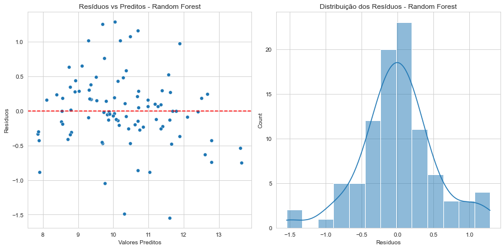

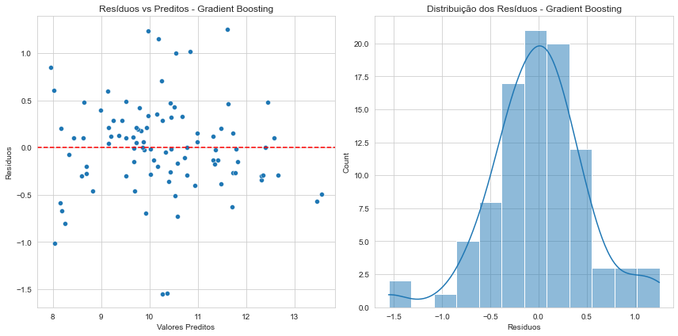

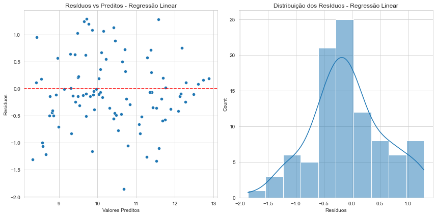

```python
# Função para plotar resíduos
def plot_residuals(y_true, y_pred, model_name):
    residuals = y_true - y_pred
    plt.figure(figsize=(12, 6))

    plt.subplot(1, 2, 1)
    sns.scatterplot(x=y_pred, y=residuals)
    plt.axhline(y=0, color='r', linestyle='--')
    plt.title(f'Resíduos vs Preditos - {model_name}')
    plt.xlabel('Valores Preditos')
    plt.ylabel('Resíduos')

    plt.subplot(1, 2, 2)
    sns.histplot(residuals, kde=True)
    plt.title(f'Distribuição dos Resíduos - {model_name}')
    plt.xlabel('Resíduos')

    plt.tight_layout()
    plt.show()

# Plotar resíduos por modelo
for model_name, model in models_baseline.items():
    y_pred = model.predict(X_test)
    plot_residuals(y_test, y_pred, model_name)
```

### 3.4. Otimização de Hiperparâmetros

Utilização de `GridSearchCV` para pesquisa dos melhores parâmetros, para indução dos modelos.

```python
# Definindo os grids de hiperparâmetros para cada modelo com comentários explicativos
param_grids = {
    'Random Forest': {
        'regressor__n_estimators': [100, 200, 300], # Número de árvores
        'regressor__max_depth': [None, 10, 20, 30], # Profundidade máxima de cada árvore (None == sem limite)
        'regressor__min_samples_split': [2, 5, 10], # Número mínimo de amostras para um nó
        'regressor__min_samples_leaf': [1, 2, 4],   # Número mínimo de amostras por folha
    },
    'Gradient Boosting': {
        'regressor__n_estimators': [50, 100, 200], # Número de estágios de boosting (árvores)
        'regressor__learning_rate': [0.01, 0.05, 0.1], # Taxa de aprendizado
        'regressor__max_depth': [3, 4, 5, 6],  # Profundidade máxima de cada estimador (árvore)
        'regressor__min_samples_split': [2, 5, 10], # Número mínimo de amostras para um nó
        'regressor__min_samples_leaf': [1, 2, 4], # Número mínimo de amostras necessárias por folha
    },
    'Regressão Linear': {
        'regressor__fit_intercept': [True, False] # Se deve calcular o intercepto (bias)
    }
}

# Otimização e avaliação dos modelos com hiperparâmetros ajustados
optimized_results = {}
best_models = {}

for name in models_baseline.keys():
    grid_search = GridSearchCV(
        estimator=models_baseline[name],
        param_grid=param_grids[name],
        cv=5,
        scoring='neg_mean_squared_error',
        n_jobs=-1)

    # Procura de parâmetros
    grid_search.fit(X_train, y_train)
    best_model = grid_search.best_estimator_
    best_models[name] = best_model

    # Treinamento do modelo otimizado
    y_pred = best_model.predict(X_test)
    mse = mean_squared_error(y_test, y_pred)
    r2 = r2_score(y_test, y_pred)

    optimized_results[name] = {
        'MSE': mse,
        'R²': r2,
        'Best Params': grid_search.best_params_
    }

# Comparação de performance após otimização
df_optimized = pd.DataFrame.from_dict(optimized_results, orient='index')
df_optimized = df_optimized[['MSE', 'R²', 'Best Params']].rename_axis('Modelo').sort_values('MSE').reset_index()

print("\nResultados após otimização:")
display(df_optimized)

## 4. Identificação do Melhor Modelo
best_model_name = df_optimized.iloc[0]['Modelo']
best_model = best_models[best_model_name]

print(f"\nMelhor modelo final: {best_model_name}")
print(f"Parâmetros otimizados: {optimized_results[best_model_name]['Best Params']}")
print(f"Performance final - MSE: {optimized_results[best_model_name]['MSE']:.4f}, R²: {optimized_results[best_model_name]['R²']:.4f}")

## 5. Comparação Entre Baseline e Otimizado
print("\nComparação entre versões baseline e otimizadas:")
comparison = pd.concat([
    df_baseline.assign(Version='Baseline'),
    df_optimized.drop(columns='Best Params').assign(Version='Otimizado')
])
display(comparison.sort_values(['Modelo', 'Version']))
```

```
Resultados após otimização:
```

|  | Modelo | MSE | R² | Best Params |
| --- | --- | --- | --- | --- |
| 0 | Random Forest | 0.228145 | 0.870994 | {'regressor__max_depth': 10, 'regressor__min_s... |
| 1 | Gradient Boosting | 0.246802 | 0.860444 | {'regressor__learning_rate': 0.05, 'regressor_... |
| 2 | Regressão Linear | 0.433304 | 0.754985 | {'regressor__fit_intercept': True} |

```
Melhor modelo final: Random Forest
Parâmetros otimizados: {'regressor__max_depth': 10, 'regressor__min_samples_leaf': 4, 'regressor__min_samples_split': 2, 'regressor__n_estimators': 300}
Performance final - MSE: 0.2281, R²: 0.8710

Comparação entre versões baseline e otimizadas:
```

|  | Modelo | MSE | R² | Version |
| --- | --- | --- | --- | --- |
| 0 | Gradient Boosting | 0.240198 | 0.864179 | Baseline |
| 1 | Gradient Boosting | 0.246802 | 0.860444 | Otimizado |
| 1 | Random Forest | 0.265813 | 0.849694 | Baseline |
| 0 | Random Forest | 0.228145 | 0.870994 | Otimizado |
| 2 | Regressão Linear | 0.433304 | 0.754985 | Baseline |
| 2 | Regressão Linear | 0.433304 | 0.754985 | Otimizado |

### 3.5. Feature Importance do melhor Modelo

`feature_importances`: Mostra a importância baseada na redução média de impureza que cada feature proporciona

```python
def plot_feature_importance(model, feature_names, model_type):
    plt.figure(figsize=(12, 8))

    if model_type in ['Random Forest', 'Gradient Boosting']:
        importances = model.named_steps['regressor'].feature_importances_

        # df importance
        importance_df = pd.DataFrame({
            'Feature': feature_names,
            'Importance': importances
        }).sort_values('Importance', ascending=True)

        # Plot
        plt.barh(importance_df['Feature'], importance_df['Importance'], color='skyblue')
        plt.title(f'Feature Importance - {model_type}\n(Quanto maior, mais importante)', pad=20)
        plt.xlabel('Importância Relativa')
        plt.grid(axis='x', linestyle='--', alpha=0.6)

        for i, v in enumerate(importance_df['Importance']):
            plt.text(v + 0.01, i, f"{v:.3f}", color='black', va='center')

    elif model_type == 'Regressão Linear':
        coef = model.named_steps['regressor'].coef_

        # df coeficientes
        coef_df = pd.DataFrame({
            'Feature': feature_names,
            'Coefficient': coef
        }).sort_values('Coefficient', key=abs, ascending=True)

        # Plot
        plt.barh(coef_df['Feature'], coef_df['Coefficient'], color='lightgreen')
        plt.title(f'Magnitude dos Coeficientes - Regressão Linear\n(Valores absolutos)', pad=20)
        plt.xlabel('Valor do Coeficiente')
        plt.grid(axis='x', linestyle='--', alpha=0.6)

        for i, v in enumerate(coef_df['Coefficient']):
            plt.text(v + 0.01 if v > 0 else v - 0.05, i, f"{v:.3f}", color='black', va='center')

        print("\nDetalhes do Modelo Linear:")
        print("\nCoeficientes detalhados:")
        for name, value in zip(feature_names, coef):
            print(f"{name}: {value:.4f}")

    plt.tight_layout()
    plt.show()
```

```python
# Nome das colunas
preprocessor.fit(X_train)
feature_names = []

# Para feature categórica
if 'cat' in preprocessor.named_transformers_:
    # OneHotEncoder - Decoder
    if hasattr(preprocessor.named_transformers_['cat'], 'get_feature_names_out'):
        cat_features = preprocessor.named_transformers_['cat'].get_feature_names_out(['VAR_2'])
        feature_names.extend(cat_features)
    else:
        feature_names.extend(['VAR_2_B', 'VAR_2_C'])

# Para features numéricas
numeric_features = ['QTD_CHOC', 'VAR_1', 'INTERACTION']
feature_names.extend(numeric_features)

print("\nFeatures utilizadas no modelo:")
print(feature_names)
```

```
Features utilizadas no modelo:
['VAR_2_A', 'VAR_2_B', 'VAR_2_C', 'QTD_CHOC', 'VAR_1', 'INTERACTION']
```

```
Análise de Feature Importance para: Random Forest
```

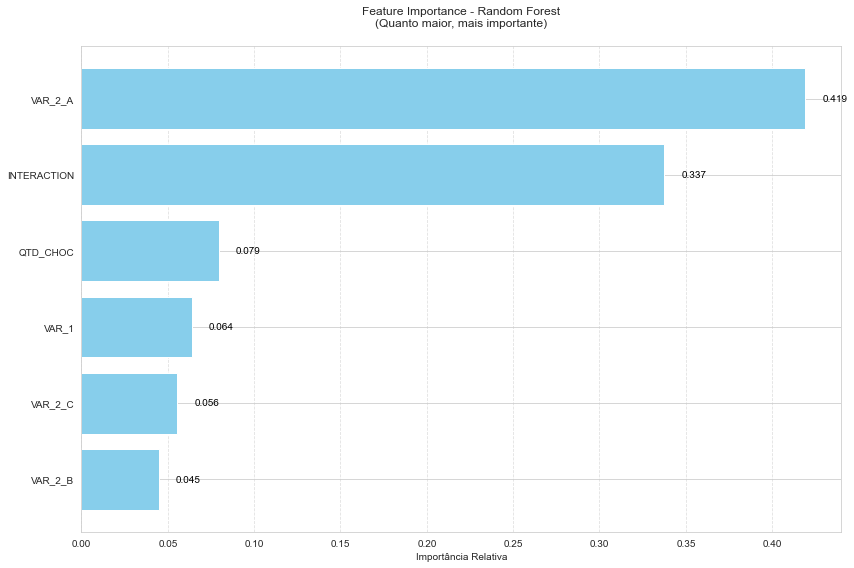

|  | Feature | Importance |
| --- | --- | --- |
| 0 | VAR_2_A | 0.419054 |
| 5 | INTERACTION | 0.337428 |
| 3 | QTD_CHOC | 0.079394 |
| 4 | VAR_1 | 0.063875 |
| 2 | VAR_2_C | 0.055510 |
| 1 | VAR_2_B | 0.044739 |

```python
# Plotando as features importances para o melhor modelo
print(f"\nAnálise de Feature Importance para: {best_model_name}")
plot_feature_importance(best_model, feature_names, best_model_name)

if best_model_name in ['Random Forest', 'Gradient Boosting']:
    importances = best_model.named_steps['regressor'].feature_importances_
    display(pd.DataFrame({'Feature': feature_names, 'Importance': importances}).sort_values('Importance', ascending=False))
```

### 3.5. Predição de Peso para novos dados

Predição de pesos, para dataset `analise_preditiva.csv`, e avaliação dos resultados

```python
df_pred = pd.read_csv("C:/Users/pcdan/Downloads/case_IBM/analise_preditiva.csv", sep=';',decimal=',', low_memory=False)

# Conversão da variável categórica
df_pred['VAR_2'] = pd.Categorical(df_pred['VAR_2'])
df_pred['PESO_BOMBOM'] = np.nan
df_pred['INTERACTION'] = df_pred['QTD_CHOC'] * df_pred['VAR_1']

X_pred = df_pred[['QTD_CHOC', 'VAR_1', 'VAR_2', 'INTERACTION']]

# Fazer predições com o melhor modelo
predict_peso_modelo = best_model.predict(X_pred)

df_pred['PESO_BOMBOM'] = predict_peso_modelo

# Função para predição individual
def predict_peso(qtd_choc, var_1, var_2, model=best_model):
    new_data = pd.DataFrame({
        'QTD_CHOC': [qtd_choc],
        'VAR_1': [var_1],
        'VAR_2': [var_2]
    })
    return model.predict(new_data)[0]
```

```python
df_pred = df_pred[['QTD_CHOC', 'VAR_1', 'VAR_2', 'PESO_BOMBOM']]
df_pred.to_csv("C:/Users/pcdan/Downloads/case_IBM/analise_preditiva_model.csv", sep=';', index=False)
df_pred.head(10)
```

|  | QTD_CHOC | VAR_1 | VAR_2 | PESO_BOMBOM |
| --- | --- | --- | --- | --- |
| 0 | 286.63 | 2.72 | A | 11.403992 |
| 1 | 257.27 | 1.97 | B | 8.481879 |
| 2 | 353.16 | 2.64 | A | 12.772345 |
| 3 | 317.78 | 2.76 | A | 11.981075 |
| 4 | 248.10 | 2.63 | C | 9.931415 |
| 5 | 301.79 | 0.93 | A | 9.896266 |
| 6 | 246.52 | 2.98 | B | 10.418446 |
| 7 | 356.48 | 2.38 | A | 12.739424 |
| 8 | 349.41 | 1.59 | B | 9.180146 |
| 9 | 282.74 | 2.11 | C | 10.618015 |